# Predicting extreme annual coral loss

A gated specialist, beta/binomial benchmark, and data priorities

## Decision

The extreme-loss specialist is useful, but it should not replace the general annual-change model.

The binomial + beta hurdle GAM below is a distributionally appropriate benchmark. It separates gain and loss occurrence from their bounded magnitudes and preserves the same bleaching modifiers and restricted-mortality transfer. It is not yet the full Bayesian latent programme-observation model.

Across unseen reefs it is competitive (RMSE 6.89 points; predictive R2 0.178) but does not repair the severe 2024 tail. In reef-blocked 2024 predictions, RMSE is 9.48 and severe transitions average -21.58 points observed versus -10.29 predicted. The underprediction is therefore not simply an artefact of an unbounded Gaussian response; the severe-event gate contributes additional predictive information.

## What the extreme specialist does

The model first estimates the probability that a transition loses at least 10 percentage points of coral cover. A second model is trained on severe annual losses plus source-balanced, bleaching-attributed relative-mortality records. It then blends that tail estimate with the mortality-augmented annual-change prediction:

$$\hat\Delta_{soft} = \hat\Delta_{base} + p_{severe}
(\hat\Delta_{tail}-\hat\Delta_{base}).$$

The aggressive sensitivity substitutes $\sqrt{p_{severe}}$ for $p_{severe}$. It therefore acts earlier and more strongly, which improves large-loss estimates at the cost of more false alarms.

The threshold is a modelling device, not a claim that ecological response is discontinuous at 10 points. All reported performance is from held-out years, reefs, or future events; the specialist is never assessed on the observations used to fit it.

## Validation trade-off

| Model | Validation | RMSE (pp) | Predictive R2 | Severe MAE (pp) | Severe underprediction (pp) | Non-severe MAE (pp) |
| --- | --- | --- | --- | --- | --- | --- |
| Aggressive extreme ensemble | Forward 2024–2025 | 10.14 | 0.042 | 14.60 | 13.73 | 5.47 |
| Aggressive extreme ensemble | Recent year held out | 8.98 | -0.076 | 12.83 | 11.42 | 5.80 |
| Aggressive extreme ensemble | Unseen reefs | 7.39 | 0.054 | 10.14 | 9.11 | 4.82 |
| Mortality-augmented base | Forward 2024–2025 | 11.22 | -0.174 | 19.30 | 17.85 | 4.82 |
| Mortality-augmented base | Recent year held out | 8.56 | 0.021 | 17.24 | 16.06 | 4.55 |
| Mortality-augmented base | Unseen reefs | 6.79 | 0.202 | 13.81 | 13.36 | 3.87 |
| Soft-gated extreme ensemble | Forward 2024–2025 | 10.59 | -0.046 | 17.10 | 16.22 | 5.04 |
| Soft-gated extreme ensemble | Recent year held out | 8.59 | 0.014 | 15.12 | 13.86 | 4.99 |
| Soft-gated extreme ensemble | Unseen reefs | 6.87 | 0.183 | 12.05 | 11.23 | 4.15 |
| Binomial + beta hurdle GAM | Forward 2024–2025 | 10.83 | -0.093 | 18.73 | 16.77 | 4.70 |
| Binomial + beta hurdle GAM | Recent year held out | 8.73 | -0.017 | 16.36 | 13.60 | 4.77 |
| Binomial + beta hurdle GAM | Unseen reefs | 6.89 | 0.178 | 13.42 | 12.93 | 4.06 |

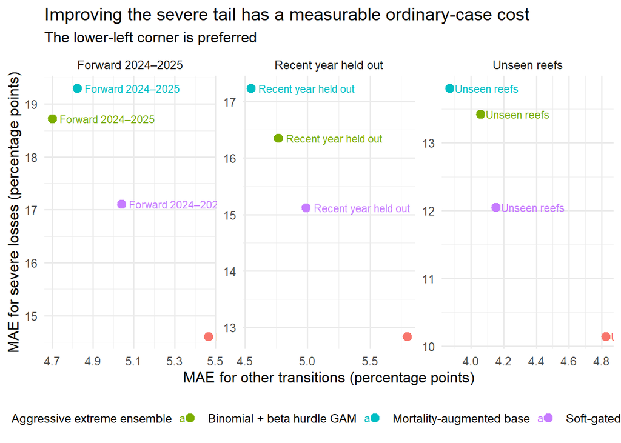

## The 2024 event

| Model | N | Observed mean (pp) | Predicted mean (pp) | RMSE (pp) | Severe observed (pp) | Severe predicted (pp) | Severe MAE (pp) | False extreme |
| --- | --- | --- | --- | --- | --- | --- | --- | --- |
| Aggressive extreme ensemble | 234 | -5.89 | -7.48 | 8.25 | -21.58 | -15.40 | 8.47 | 14.1% |
| Mortality-augmented base | 234 | -5.89 | -4.52 | 8.59 | -21.58 | -11.14 | 11.43 | 4.3% |
| Soft-gated extreme ensemble | 234 | -5.89 | -5.99 | 8.13 | -21.58 | -13.98 | 9.67 | 9.4% |

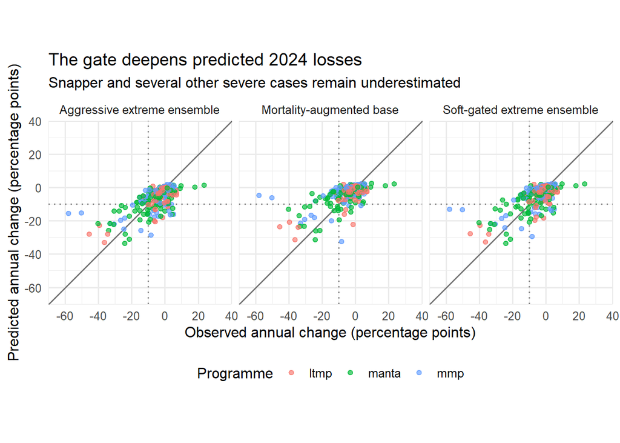

### Largest remaining misses

| Reef | Programme | Observed | Predicted | Error | Severe probability | DHW | Acropora | WQC | Cyclone wave h | Annotation |
| --- | --- | --- | --- | --- | --- | --- | --- | --- | --- | --- |
| Snapper Reef (16-006) | mmp | -57.9 | -13.0 | -44.9 | 58% | 6.9 | 14% | 0.90 | 0 | Jasper Cyclone Jasper, flood waters at 2.0 m only, coral bleaching at 5.0 m only \| flood waters, Cyclone Jasper |
| Snapper Reef (16-006) | mmp | -50.3 | -13.3 | -37.0 | 61% | 6.9 | 23% | 0.90 | 0 | Jasper Cyclone Jasper, flood waters at 2.0 m only, coral bleaching at 5.0 m only \| flood waters, Cyclone Jasper |
| U/N Reef (20-104) | manta | 23.3 | 2.1 | 21.2 | 0% | 5.6 | 21% | 0.00 | 26 | NA |
| Barren Island Reef (22-009) | mmp | -8.3 | -29.3 | 21.0 | 67% | 11.1 | 93% | 1.00 | 0 | bleaching still evident at time of surveys coral bleaching |
| Rebe Reef (19-209) | manta | 4.3 | -15.2 | 19.5 | 75% | 10.3 | 64% | 0.00 | 33 | NA |
| North Direction Reef (14-143) | manta | -40.2 | -21.2 | -19.0 | 88% | 6.2 | 44% | 0.02 | 0 | DHW 6.23 aerial bl 5 coral bleaching |
| Mackay Reef (16-015) | manta | -26.0 | -7.6 | -18.5 | 30% | 3.8 | 11% | 0.07 | 0 | DHW 4.03 coral bleaching, Cyclone Jasper, flood waters |
| Round-Russell Reef (17-013) | mmp | 5.1 | -13.1 | 18.2 | 56% | 6.4 | 0% | 0.45 | 0 | COTS seen this year and last, but also BrB disease \| combination of flood, COTS, minor bleachng crown-of-thorns starfish \| unknown at 2.0 m only |
| Linnet Reef (14-126) | manta | -30.6 | -12.7 | -17.9 | 17% | 6.7 | 63% | 0.54 | 0 | DHW 6.73 coral bleaching |
| One Tree Island Reef (23-055a) | ltmp | -45.6 | -27.7 | -17.9 | 88% | 11.6 | 92% | 0.05 | 0 | DHW 11 coral bleaching, coral disease |
| Tobias Spit (17-009a) | mmp | 3.3 | -13.9 | 17.2 | 31% | 6.3 | 27% | 0.75 | 0 | clear depth limit to level of mortality flood waters at 2.0 m only, Cyclone Jasper at 2.0 m only, crown-of-thorns starfish at 5.0 m only |
| Broomfield Reef (23-048) | ltmp | -39.6 | -22.6 | -17.0 | 88% | 11.6 | 86% | 0.04 | 0 | Aerial bl 5 2024 DHW 11.6 coral bleaching, unknown storm |
| Davie Reef (13-130) | ltmp | -1.5 | -18.4 | 16.9 | 89% | 7.0 | 42% | 0.20 | 0 | NA |
| U/N Reef (19-138) | manta | 18.0 | 1.1 | 16.8 | 1% | 5.8 | 20% | 0.00 | 21 | NA |
| Slate Reef (19-159) | manta | 4.6 | -12.0 | 16.6 | 80% | 8.6 | 61% | 0.00 | 33 | NA |
| Stingaree Reefs (17-053) | mmp | 2.4 | -12.6 | 15.0 | 66% | 4.0 | 62% | 0.94 | 0 | partial bleaching at time of surveys coral bleaching |
| Erskine Reef (23-068) | manta | -2.7 | -17.0 | 14.3 | 91% | 11.2 | 82% | 0.03 | 0 | Aerial bl 4 2024 DHW 11.17 coral bleaching |
| U/N Reef (21-187) | manta | -27.6 | -13.5 | -14.1 | 59% | 7.2 | 31% | 0.00 | 0 | NA |

The most informative errors now fall into two groups:

1. Large observed losses still predicted too mildly, especially where a short, event-timed freshwater or cyclone exposure is poorly represented by a wet-season mean.
2. False severe predictions where heat, community and pressure covariates look hazardous but mortality did not occur. These reefs are essential controls for learning resistance, refuge and observation differences.

## Binomial + beta annual-change benchmark

The benchmark uses four components: binomial gain occurrence, beta gain magnitude conditional on gain, Bernoulli loss occurrence, and beta loss magnitude conditional on loss. Expected change is bounded by both current cover and available space:

$$C_{t+1}=C_t+(1-C_t)P(G)E(G\mid G)-C_tP(L)E(L\mid L).$$

This is a hurdle construction, not a beta-binomial count distribution. A true count-binomial observation layer requires the number of scored colonies or points, which is not consistently available in the harmonised annual data.

| Validation | N | RMSE (pp) | Predictive R2 | Severe MAE (pp) | Severe underprediction (pp) | Non-severe MAE (pp) |
| --- | --- | --- | --- | --- | --- | --- |
| Forward 2024–2025 | 339 | 10.83 | -0.093 | 18.73 | 16.77 | 4.70 |
| Recent year held out | 1215 | 8.73 | -0.017 | 16.36 | 13.60 | 4.77 |
| Unseen reefs | 3089 | 6.89 | 0.178 | 13.42 | 12.93 | 4.06 |

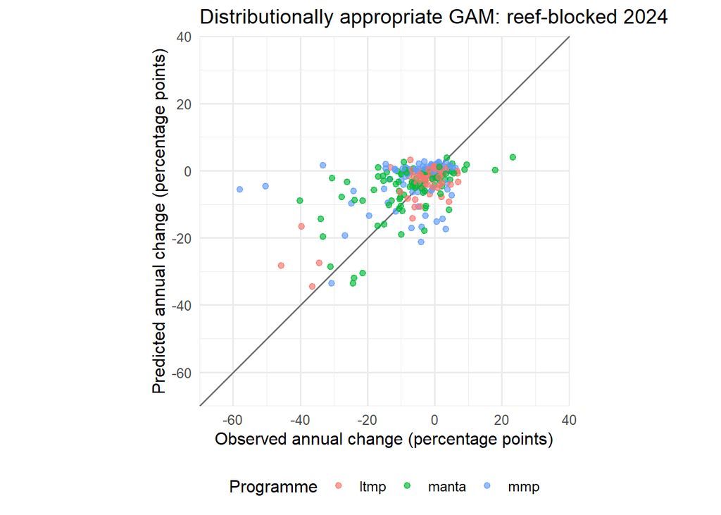

## Data most likely to explain the misses

| Priority | Data and immediate use | Mechanism or ambiguity addressed | Operational note |
| --- | --- | --- | --- |
| 1 | **MMP event salinity, TSS, CDOM, Secchi and logger time series**; use measured events to calibrate a daily freshwater-exposure reconstruction | Distinguishes genuine low-salinity stress from merely coloured or turbid water. The 2023–24 observations include extreme Jasper freshwater conditions | Direct observations are spatially sparse but uniquely valuable for calibration |
| 1 | **Queensland river discharge and catchment runoff**, routed to reefs using plume travel time/connectivity | Captures short freshwater pulses that a seasonal WQC frequency or coastal rainfall total can miss | Available quickly enough for operational event prediction once the reef–catchment linkage is built |
| 1 | **Raw AIMS manta, LTMP and MMP records**: dominant lifeform/genera, disease, Drupella, unknown scars, visibility, sea state, wind and tide | Tests whether severe losses reflect community susceptibility, unrecorded biological disturbance, or observation conditions | The downloaded local manta summary omits these fields; raw tow/transect data need to be requested or acquired |
| 2 | **BoM cyclone best tracks plus event rainfall/wind**, converted to distance, intensity, storm-side and duration metrics | Detects Jasper/Kirrily/Debbie exposure when the RRN 4 m-wave variable is zero or spatially mismatched | Retain RRN wave hours; this adds complementary wind/rain/freshwater exposure |
| 2 | **2024 aerial bleaching severity** as an early-event gate covariate | Provides spatial evidence that physiological damage occurred before later mortality surveys | Use for within-event nowcasting, not as a timeless pre-event predictor or mortality label |
| 2 | **GBR10 habitat, reef zone, slope, depth, exposure and hard substrate** | Represents refuge, hydrodynamic flushing, habitat-specific community structure and the attainable cover ceiling | Static and suitable for all-GBR prediction |
| 2 | **Functional community composition**: branching/tabular Acropora, other fast-growing taxa, massive/slow-growing taxa and recent recovery trajectory | `% Acropora` alone cannot distinguish highly susceptible assemblages or weedy post-disturbance recovery states | Derive from image/transect data where available; spatial imputation will be required elsewhere |
| 3 | **Daily plume trajectory metrics** from ocean colour and rainfall: anomaly, percentile, consecutive exposure days, timing relative to peak DHW and recovery time | A wet-season mean can hide brief compound freshwater–heat episodes | Preserve raw products because chlorophyll can be confounded by sediment/CDOM after cyclones |
| 3 | **In-situ temperature extremes and diurnal variability** | Satellite DHW may miss shallow lagoon heat, cold/freshwater coincidence and local mixing | Logger coverage is sparse; use for calibration and local correction rather than blanket replacement |

The RRN workbook contributes all of its acute pressure series to the current pipeline: DHW, cyclone-wave exposure, COTS and water colour. Coral-sink connectivity was the only unused individual-pressure field and has now been added for modelling recovery. The workbook’s composite metrics recombine these components and can mix temporal windows, so they are not preferable predictors for diagnosing acute 2024 loss.

Useful source entry points are the [GBRMPA Reef Recovery Network tool](https://reefknowledgesystem.gbrmpa.gov.au/node/426), [AIMS eReefs freshwater-exposure portal](https://ereefs.aims.gov.au/gbr1/fresh-water-exposure/), [AIMS MMP water-quality observations](https://apps.aims.gov.au/metadata/view/a5a02dc8-16b4-4b50-abad-af4a1c1e9c49), [Queensland water monitoring](https://www.qld.gov.au/environment/water/quality/monitoring), [BoM tropical-cyclone history](https://www.bom.gov.au/cyclone/history/), [AIMS agents-of-mortality records](https://apps.aims.gov.au/metadata/view/5b6f05b0-4ade-11dc-8f56-00008a07204e), [AIMS manta-tow metadata](https://apps.aims.gov.au/metadata/view/5bb9a340-4ade-11dc-8f56-00008a07204e), [2024 aerial bleaching observations](https://apps.aims.gov.au/metadata/view/3fd37e52-12cf-4b59-8873-96b82bc955c9), and the [GBR10 benthic habitat map](https://researchdata.edu.au/great-barrier-reef-gbrmp-benthic/3921909/).

## Recommended operational ensemble

Do not choose a single model by global RMSE alone. Carry three outputs into the next stage:

1. **Central estimate:** the general decomposed/latent model, optionally blended with the soft-gated specialist after its weight is selected strictly within validation folds.
2. **Severe-risk estimate:** the aggressive gate, reported as a risk-sensitive scenario rather than silently replacing the mean.
3. **Uncertainty and trigger:** the gate probability plus disagreement between general and tail experts. Large disagreement identifies reefs requiring field confirmation or scenario widening.

The blend weight and severe threshold should next be tuned with nested reef/year validation against an explicit cost function. That function should penalise missed severe losses more than ordinary error while retaining a hard report on false severe alarms. A reasonable starting rule is to minimise overall MAE plus twice the severe-loss MAE, subject to a maximum false-extreme rate agreed for the operational product. The threshold, weight and loss ratio must be locked before the final untouched event assessment.

The next formal modelling step remains a Bayesian latent annual-cover model with programme-specific observation layers. Its shared ecological state should retain the gain/loss decomposition, the best modifiers, and a mixture or heavy-tailed disturbance component. The tree specialist can then be stacked with its out-of-fold predictions rather than being substituted for it.